# Information About Real Estate Properties in Tashkent, Uzbekistan by Olanisebe Taiwo

## Analysis Overview

In this analysis, I decided to pay attention to the composition and distribution of real estate properties in the districts of Tashkent, the capital of Uzbekistan, and how these information relate with the price of real estate properties in the State.

## Dataset Overview

This dataset consists of numerous attributes of more than 7,000 real estate properties that are up for sale in 12 districts in Tashkent, Uzbekistan. The various attributes in this data set include the address of properties, the districts of the state in which properties are located, the number of rooms each property comes with, the size of properties in square metres, the level or floor in which these properties are located, the maximum number of floors the building in which properties are located have, the price of properties and the longitude and latitude of properties.

## Distribution of Real Estate Properties Among the Districts of Uzbekistan's Capital City.

The districts of Tashkent, provided in this dataset, accomodate numerous amounts of real estate properties up for sale. The Chilonzor district has the most real estate properties up for sale with over 1600 properties, while the Bektemir district has the least amount of properties up for sale with a count of just 8 properties.

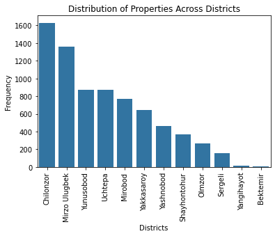

## Number of Rooms Real Estate Properties Are Built With.

7 out of the 12 districts present in this dataset, mostly have 2 room properties up for sale in them with the rest having 2 room properties as the second most popular properties up for sale. It shows that people who generally own properties and live in Tashkent do not have large families.

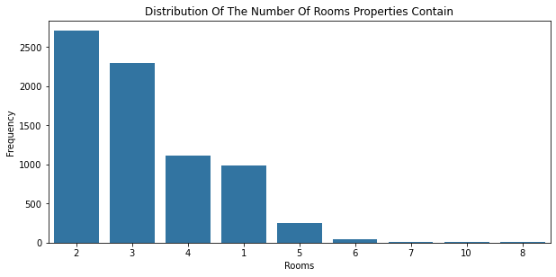

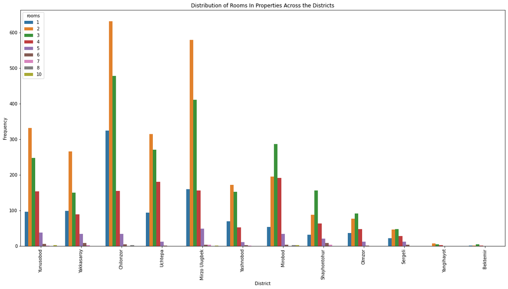

## Average Price of Real Estate Properties Across Districts

Houses on average in Tashkent, generally cost below 100,000 USD. Also, the Mirobod district is glaringly the most expenisve district on average, with the Bektemir district being the district that boasts the cheapest real estate properties up for sale on the market.

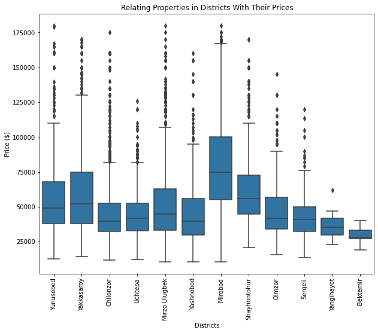

## Price by District and Room Size of Property

Real estate properties tend to see an increase in price as the number of rooms they possess increases across the districts in this dataset. This follows societal norms as bigger roomed properties are ideally expensive than smaller ones in same areas.

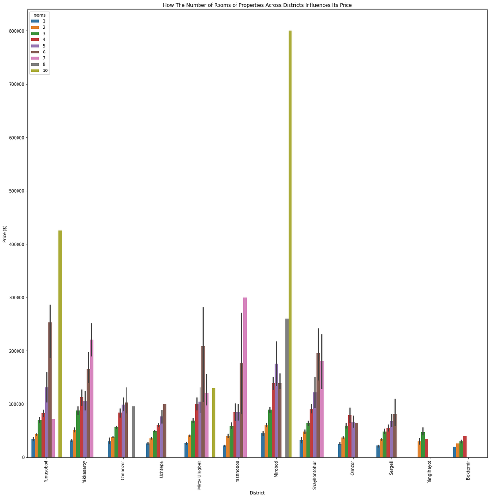

## Price by Size of Properties across Districts

Scatterplots relating the price of real estate properties to their sizes show a positive correlation, therefore showing that an increase in the size of real estate properties across the various districts in this dataset brings about an increase in the price of said properties.

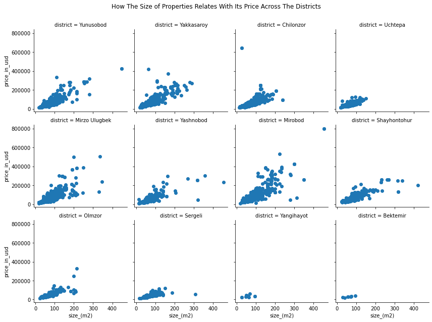